# Memo - Examining PM2.5 time series data

2/2/2021

## Objectives

In the analyses to date, the result for PM2.5 appears clear but we want to make sure we understand what’s happening under the hood. We see a significant increase in PM2.5 concentrations with an additonal well within 3 km both upwind, but not downwind, from monitors. In this memo, I examine the raw observations, exposure metrics, and residuals.

## Analysis

| monitor_id | carb_basin | county | is_urban |
| --- | --- | --- | --- |
| 060210003 | Sacramento Valley | Glenn | 1 |
| 060290014 | San Joaquin Valley | Kern | 1 |
| 060371602 | South Coast | Los Angeles | 1 |
| 060374002 | South Coast | Los Angeles | 1 |
| 060374004 | South Coast | Los Angeles | 1 |

Data for exposed monitor-days (within 3 km) with PM2.5 observations come from five monitors, all of which are urban and located in the Central Valley or Los Angeles County.

#### Plot. Exposure by year

The colors correspond with different monitors

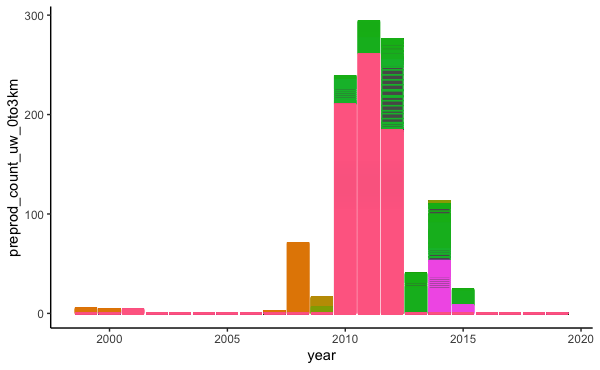

Exposure at the monitors is concentrated in 2008-2015

#### Plot. Correlation between upwind and downwind exposure among exposed monitors

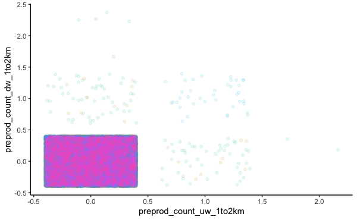

Some correlation between exposure to upwind and downwind wells

#### Plot. Residuals x upwind exposure, exposed monitors only

Residuals from adjust linear regression model with meteorological and day-of-week controls with FE for basin-month and basin-year.

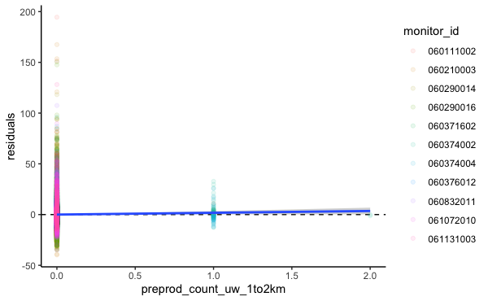

This is our primary positive result for PM2.5

#### Plot. Residuals x downwind placebo “exposure,” exposed monitors only

Residuals from adjust linear regression model with meteorological and day-of-week controls with FE for basin-month and basin-year.

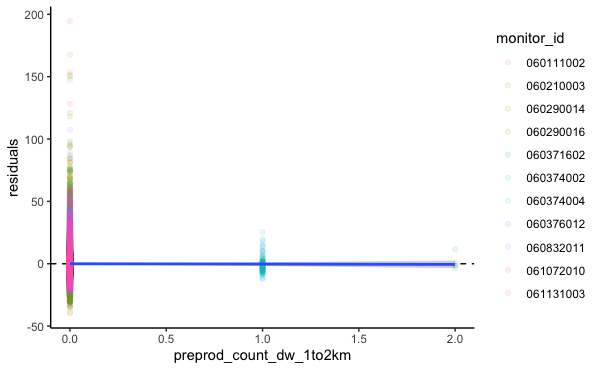

A null result as we had anticipated

#### Plot. Residuals x upwind exposure, all monitors

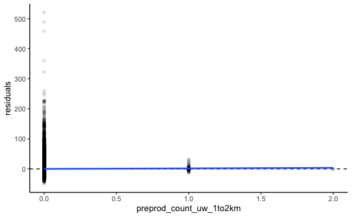

#### Plot. Time series of PM2.5 at monitor 060290014 (Kern County)

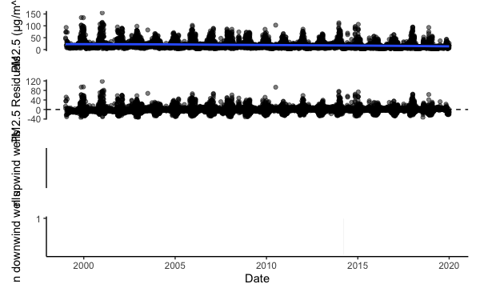

Monitor 060290014 unfortunately only has 3 exposure days with wells at 2-3 km, and the rest of the exposure at 3+ km

#### Plot. Time series of PM2.5 at monitor 060374002 (Los Angeles)

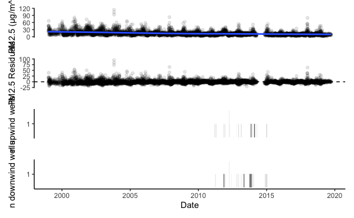

#### Plot. Time series of PM2.5 at monitor 060374004 (Los Angeles)

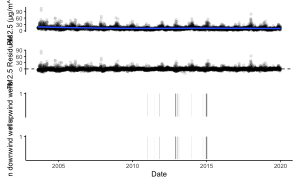